# Risk Factor Analysis

## Outcome Variable

**Outcome Variable:** stunted

## Predictor Variables

**Intervention Variable:** impfloor

**Adjustment Set:**

- arm
- sex
- W_mage
- meducyrs
- feducyrs
- hhwealth_quart
- hfoodsec
- W_mhtcm
- W_nrooms
- W_nchldlt5
- W_parity
- impsan
- safeh20
- delta_W_mage
- delta_meducyrs
- delta_feducyrs
- delta_hhwealth_quart
- delta_hfoodsec
- delta_W_mhtcm
- delta_W_nrooms
- delta_W_nchldlt5
- delta_W_parity
- delta_impsan
- delta_safeh20

## Stratifying Variables

The analysis was stratified on these variable(s):

- agecat
- studyid
- country

## Data Summary

| agecat | studyid | country | impfloor | stunted | n_cell | n |
| --- | --- | --- | --- | --- | --- | --- |
| Birth | ki0047075b-MAL-ED | BANGLADESH | 0 | 0 | 16 | 234 |
| Birth | ki0047075b-MAL-ED | BANGLADESH | 0 | 1 | 2 | 234 |
| Birth | ki0047075b-MAL-ED | BANGLADESH | 1 | 0 | 180 | 234 |
| Birth | ki0047075b-MAL-ED | BANGLADESH | 1 | 1 | 36 | 234 |
| 6 months | ki0047075b-MAL-ED | BANGLADESH | 0 | 0 | 17 | 240 |
| 6 months | ki0047075b-MAL-ED | BANGLADESH | 0 | 1 | 2 | 240 |
| 6 months | ki0047075b-MAL-ED | BANGLADESH | 1 | 0 | 178 | 240 |
| 6 months | ki0047075b-MAL-ED | BANGLADESH | 1 | 1 | 43 | 240 |
| 24 months | ki0047075b-MAL-ED | BANGLADESH | 0 | 0 | 8 | 212 |
| 24 months | ki0047075b-MAL-ED | BANGLADESH | 0 | 1 | 9 | 212 |
| 24 months | ki0047075b-MAL-ED | BANGLADESH | 1 | 0 | 106 | 212 |
| 24 months | ki0047075b-MAL-ED | BANGLADESH | 1 | 1 | 89 | 212 |
| Birth | ki0047075b-MAL-ED | BRAZIL | 0 | 0 | 2 | 174 |
| Birth | ki0047075b-MAL-ED | BRAZIL | 0 | 1 | 0 | 174 |
| Birth | ki0047075b-MAL-ED | BRAZIL | 1 | 0 | 155 | 174 |
| Birth | ki0047075b-MAL-ED | BRAZIL | 1 | 1 | 17 | 174 |
| 6 months | ki0047075b-MAL-ED | BRAZIL | 0 | 0 | 2 | 209 |
| 6 months | ki0047075b-MAL-ED | BRAZIL | 0 | 1 | 0 | 209 |
| 6 months | ki0047075b-MAL-ED | BRAZIL | 1 | 0 | 201 | 209 |
| 6 months | ki0047075b-MAL-ED | BRAZIL | 1 | 1 | 6 | 209 |
| 24 months | ki0047075b-MAL-ED | BRAZIL | 0 | 0 | 2 | 169 |
| 24 months | ki0047075b-MAL-ED | BRAZIL | 0 | 1 | 0 | 169 |
| 24 months | ki0047075b-MAL-ED | BRAZIL | 1 | 0 | 161 | 169 |
| 24 months | ki0047075b-MAL-ED | BRAZIL | 1 | 1 | 6 | 169 |
| Birth | ki0047075b-MAL-ED | INDIA | 0 | 0 | 9 | 191 |
| Birth | ki0047075b-MAL-ED | INDIA | 0 | 1 | 1 | 191 |
| Birth | ki0047075b-MAL-ED | INDIA | 1 | 0 | 152 | 191 |
| Birth | ki0047075b-MAL-ED | INDIA | 1 | 1 | 29 | 191 |
| 6 months | ki0047075b-MAL-ED | INDIA | 0 | 0 | 11 | 235 |
| 6 months | ki0047075b-MAL-ED | INDIA | 0 | 1 | 4 | 235 |

[output cut: 139 more lines]

The following strata were considered:

- agecat: 24 months, studyid: ki0047075b-MAL-ED, country: BANGLADESH
- agecat: 24 months, studyid: ki0047075b-MAL-ED, country: BRAZIL
- agecat: 24 months, studyid: ki0047075b-MAL-ED, country: INDIA
- agecat: 24 months, studyid: ki0047075b-MAL-ED, country: NEPAL
- agecat: 24 months, studyid: ki0047075b-MAL-ED, country: PERU
- agecat: 24 months, studyid: ki0047075b-MAL-ED, country: SOUTH AFRICA
- agecat: 24 months, studyid: ki0047075b-MAL-ED, country: TANZANIA, UNITED REPUBLIC OF
- agecat: 24 months, studyid: ki1000108-CMC-V-BCS-2002, country: INDIA
- agecat: 24 months, studyid: ki1000108-IRC, country: INDIA
- agecat: 24 months, studyid: ki1017093-NIH-Birth, country: BANGLADESH
- agecat: 24 months, studyid: ki1017093b-PROVIDE, country: BANGLADESH
- agecat: 24 months, studyid: ki1017093c-NIH-Crypto, country: BANGLADESH
- agecat: 24 months, studyid: ki1113344-GMS-Nepal, country: NEPAL
- agecat: 24 months, studyid: ki1114097-CONTENT, country: PERU
- agecat: 24 months, studyid: kiGH5241-JiVitA-3, country: BANGLADESH
- agecat: 24 months, studyid: kiGH5241-JiVitA-4, country: BANGLADESH
- agecat: 6 months, studyid: ki0047075b-MAL-ED, country: BANGLADESH
- agecat: 6 months, studyid: ki0047075b-MAL-ED, country: BRAZIL
- agecat: 6 months, studyid: ki0047075b-MAL-ED, country: INDIA
- agecat: 6 months, studyid: ki0047075b-MAL-ED, country: NEPAL
- agecat: 6 months, studyid: ki0047075b-MAL-ED, country: PERU
- agecat: 6 months, studyid: ki0047075b-MAL-ED, country: SOUTH AFRICA
- agecat: 6 months, studyid: ki0047075b-MAL-ED, country: TANZANIA, UNITED REPUBLIC OF
- agecat: 6 months, studyid: ki1000108-CMC-V-BCS-2002, country: INDIA
- agecat: 6 months, studyid: ki1000108-IRC, country: INDIA
- agecat: 6 months, studyid: ki1017093-NIH-Birth, country: BANGLADESH
- agecat: 6 months, studyid: ki1017093b-PROVIDE, country: BANGLADESH
- agecat: 6 months, studyid: ki1017093c-NIH-Crypto, country: BANGLADESH
- agecat: 6 months, studyid: ki1113344-GMS-Nepal, country: NEPAL
- agecat: 6 months, studyid: ki1114097-CONTENT, country: PERU
- agecat: 6 months, studyid: kiGH5241-JiVitA-3, country: BANGLADESH
- agecat: 6 months, studyid: kiGH5241-JiVitA-4, country: BANGLADESH
- agecat: Birth, studyid: ki0047075b-MAL-ED, country: BANGLADESH
- agecat: Birth, studyid: ki0047075b-MAL-ED, country: BRAZIL
- agecat: Birth, studyid: ki0047075b-MAL-ED, country: INDIA
- agecat: Birth, studyid: ki0047075b-MAL-ED, country: NEPAL
- agecat: Birth, studyid: ki0047075b-MAL-ED, country: PERU
- agecat: Birth, studyid: ki0047075b-MAL-ED, country: SOUTH AFRICA
- agecat: Birth, studyid: ki0047075b-MAL-ED, country: TANZANIA, UNITED REPUBLIC OF
- agecat: Birth, studyid: ki1000108-CMC-V-BCS-2002, country: INDIA
- agecat: Birth, studyid: ki1000108-IRC, country: INDIA
- agecat: Birth, studyid: ki1017093-NIH-Birth, country: BANGLADESH
- agecat: Birth, studyid: ki1017093c-NIH-Crypto, country: BANGLADESH
- agecat: Birth, studyid: ki1114097-CONTENT, country: PERU
- agecat: Birth, studyid: kiGH5241-JiVitA-3, country: BANGLADESH
- agecat: Birth, studyid: kiGH5241-JiVitA-4, country: BANGLADESH

### Dropped Strata

Some strata were dropped due to rare outcomes:

- agecat: Birth, studyid: ki0047075b-MAL-ED, country: BANGLADESH
- agecat: 6 months, studyid: ki0047075b-MAL-ED, country: BANGLADESH
- agecat: Birth, studyid: ki0047075b-MAL-ED, country: BRAZIL
- agecat: 6 months, studyid: ki0047075b-MAL-ED, country: BRAZIL
- agecat: 24 months, studyid: ki0047075b-MAL-ED, country: BRAZIL
- agecat: Birth, studyid: ki0047075b-MAL-ED, country: INDIA
- agecat: 6 months, studyid: ki0047075b-MAL-ED, country: INDIA
- agecat: Birth, studyid: ki0047075b-MAL-ED, country: SOUTH AFRICA
- agecat: 6 months, studyid: ki0047075b-MAL-ED, country: SOUTH AFRICA
- agecat: Birth, studyid: ki0047075b-MAL-ED, country: TANZANIA, UNITED REPUBLIC OF
- agecat: 6 months, studyid: ki0047075b-MAL-ED, country: TANZANIA, UNITED REPUBLIC OF
- agecat: 24 months, studyid: ki0047075b-MAL-ED, country: TANZANIA, UNITED REPUBLIC OF
- agecat: Birth, studyid: ki1017093-NIH-Birth, country: BANGLADESH
- agecat: Birth, studyid: ki1017093c-NIH-Crypto, country: BANGLADESH
- agecat: 6 months, studyid: ki1114097-CONTENT, country: PERU
- agecat: 24 months, studyid: ki1114097-CONTENT, country: PERU
- agecat: Birth, studyid: ki1114097-CONTENT, country: PERU

## Methods Detail

We’re interested in the causal parameters $E[Y_a]$ for all values of $a \in \mathcal{A}$. These parameters represent the mean outcome if, possibly contrary to fact, we intervened to set all units to have $A=a$. Under the randomization and positivity assumptions, these are identified by the statistical parameters $\psi_a=E_W[E_{Y|A,W}(Y|A=a,W)]$. In addition, we’re interested in the mean of $Y$, $E[Y]$ under no intervention (the observed mean). We will estimate these parameters by using SuperLearner to fit the relevant likelihood factors – $E_{Y|A,W}(Y|A=a,W)$ and $p(A=a|W)$, and then updating our likelihood fit using a joint TMLE.

For unadjusted analyses ($W=\{\}$), initial likelihoods were estimated using Lrnr_glm to estimate the simple $E(Y|A)$ and Lrnr_mean to estimate $p(A)$. For adjusted analyses, a small library containing Lrnr_glmnet, Lrnr_xgboost, and Lrnr_mean was used.

Having estimated these parameters, we will then use the delta method to estimate relative risks and attributable risks relative to a prespecified baseline level of $A$.

```
##         stunted
## impfloor   0   1
##        0   0   0
##        1  80 180
##         stunted
## impfloor   0   1
##        0   0   0
##        1 190 115
##         stunted
## impfloor   0   1
##        0   0   0
##        1 170  87
##         stunted
## impfloor   0   1
##        0   0   0
##        1 235  68
##         stunted
## impfloor  0  1
##        0  0  0
##        1 58 13
##         stunted
## impfloor   0   1
##        0   0   0
##        1 255  32
```

# Results Detail

## Results Plots

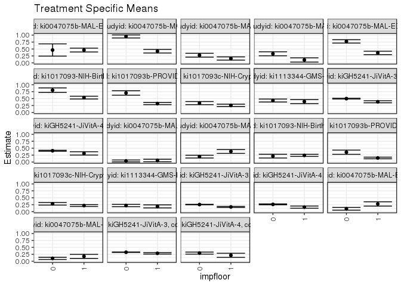

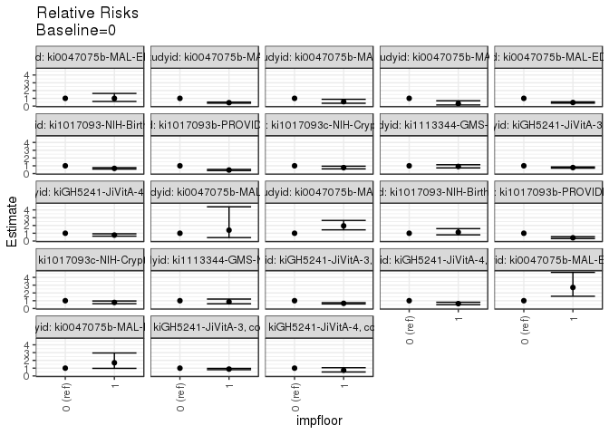

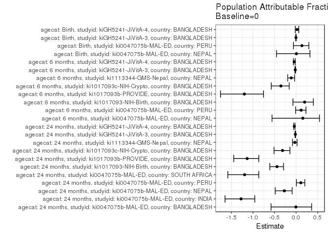

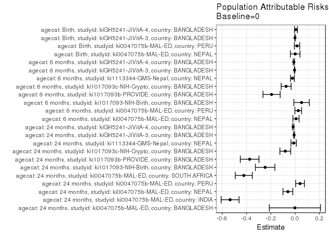

## Results Table

### Parameter: TSM

| agecat | studyid | country | intervention_level | baseline_level | estimate | ci_lower | ci_upper |
| --- | --- | --- | --- | --- | --- | --- | --- |
| Birth | ki0047075b-MAL-ED | NEPAL | 0 | NA | 0.1028806 | 0.0546493 | 0.1511119 |
| Birth | ki0047075b-MAL-ED | NEPAL | 1 | NA | 0.2778790 | 0.2007210 | 0.3550371 |
| Birth | ki0047075b-MAL-ED | PERU | 0 | NA | 0.1034313 | 0.0628467 | 0.1440159 |
| Birth | ki0047075b-MAL-ED | PERU | 1 | NA | 0.1752880 | 0.1012795 | 0.2492965 |
| Birth | kiGH5241-JiVitA-3 | BANGLADESH | 0 | NA | 0.3242438 | 0.3164594 | 0.3320282 |
| Birth | kiGH5241-JiVitA-3 | BANGLADESH | 1 | NA | 0.2853992 | 0.2583618 | 0.3124365 |
| Birth | kiGH5241-JiVitA-4 | BANGLADESH | 0 | NA | 0.2934520 | 0.2569408 | 0.3299633 |
| Birth | kiGH5241-JiVitA-4 | BANGLADESH | 1 | NA | 0.2144505 | 0.1403394 | 0.2885615 |
| 6 months | ki0047075b-MAL-ED | NEPAL | 0 | NA | 0.0405074 | 0.0064484 | 0.0745664 |
| 6 months | ki0047075b-MAL-ED | NEPAL | 1 | NA | 0.0565227 | 0.0117140 | 0.1013313 |
| 6 months | ki0047075b-MAL-ED | PERU | 0 | NA | 0.1961369 | 0.1462003 | 0.2460736 |
| 6 months | ki0047075b-MAL-ED | PERU | 1 | NA | 0.3825584 | 0.3128918 | 0.4522250 |
| 6 months | ki1017093-NIH-Birth | BANGLADESH | 0 | NA | 0.2141511 | 0.1464535 | 0.2818486 |
| 6 months | ki1017093-NIH-Birth | BANGLADESH | 1 | NA | 0.2412917 | 0.2034594 | 0.2791240 |
| 6 months | ki1017093b-PROVIDE | BANGLADESH | 0 | NA | 0.3547294 | 0.2782574 | 0.4312013 |
| 6 months | ki1017093b-PROVIDE | BANGLADESH | 1 | NA | 0.1478504 | 0.1182137 | 0.1774870 |
| 6 months | ki1017093c-NIH-Crypto | BANGLADESH | 0 | NA | 0.2836382 | 0.2371454 | 0.3301310 |
| 6 months | ki1017093c-NIH-Crypto | BANGLADESH | 1 | NA | 0.2191111 | 0.1858198 | 0.2524024 |
| 6 months | ki1113344-GMS-Nepal | NEPAL | 0 | NA | 0.2217214 | 0.1803433 | 0.2630996 |
| 6 months | ki1113344-GMS-Nepal | NEPAL | 1 | NA | 0.1899224 | 0.1347720 | 0.2450728 |
| 6 months | kiGH5241-JiVitA-3 | BANGLADESH | 0 | NA | 0.2561607 | 0.2478762 | 0.2644453 |
| 6 months | kiGH5241-JiVitA-3 | BANGLADESH | 1 | NA | 0.1694587 | 0.1490772 | 0.1898403 |
| 6 months | kiGH5241-JiVitA-4 | BANGLADESH | 0 | NA | 0.2628001 | 0.2475716 | 0.2780287 |
| 6 months | kiGH5241-JiVitA-4 | BANGLADESH | 1 | NA | 0.1632740 | 0.1233773 | 0.2031707 |
| 24 months | ki0047075b-MAL-ED | BANGLADESH | 0 | NA | 0.4641604 | 0.2435815 | 0.6847393 |
| 24 months | ki0047075b-MAL-ED | BANGLADESH | 1 | NA | 0.4621053 | 0.3922877 | 0.5319228 |
| 24 months | ki0047075b-MAL-ED | INDIA | 0 | NA | 0.9532209 | 0.8989641 | 1.0074778 |
| 24 months | ki0047075b-MAL-ED | INDIA | 1 | NA | 0.4207655 | 0.3555403 | 0.4859907 |
| 24 months | ki0047075b-MAL-ED | NEPAL | 0 | NA | 0.2763637 | 0.2071006 | 0.3456268 |
| 24 months | ki0047075b-MAL-ED | NEPAL | 1 | NA | 0.1572659 | 0.0985908 | 0.2159410 |
| 24 months | ki0047075b-MAL-ED | PERU | 0 | NA | 0.3275325 | 0.2551666 | 0.3998983 |
| 24 months | ki0047075b-MAL-ED | PERU | 1 | NA | 0.1051571 | 0.0290000 | 0.1813143 |
| 24 months | ki0047075b-MAL-ED | SOUTH AFRICA | 0 | NA | 0.7748011 | 0.7133061 | 0.8362961 |
| 24 months | ki0047075b-MAL-ED | SOUTH AFRICA | 1 | NA | 0.3582353 | 0.2961899 | 0.4202807 |
| 24 months | ki1017093-NIH-Birth | BANGLADESH | 0 | NA | 0.8039622 | 0.7224559 | 0.8854686 |
| 24 months | ki1017093-NIH-Birth | BANGLADESH | 1 | NA | 0.5357112 | 0.4859950 | 0.5854275 |
| 24 months | ki1017093b-PROVIDE | BANGLADESH | 0 | NA | 0.7032660 | 0.6241976 | 0.7823344 |
| 24 months | ki1017093b-PROVIDE | BANGLADESH | 1 | NA | 0.3206212 | 0.2814180 | 0.3598245 |
| 24 months | ki1017093c-NIH-Crypto | BANGLADESH | 0 | NA | 0.3375203 | 0.2820532 | 0.3929873 |
| 24 months | ki1017093c-NIH-Crypto | BANGLADESH | 1 | NA | 0.2564540 | 0.2134645 | 0.2994436 |
| 24 months | ki1113344-GMS-Nepal | NEPAL | 0 | NA | 0.4301255 | 0.3769104 | 0.4833406 |
| 24 months | ki1113344-GMS-Nepal | NEPAL | 1 | NA | 0.3914351 | 0.3184101 | 0.4644600 |
| 24 months | kiGH5241-JiVitA-3 | BANGLADESH | 0 | NA | 0.4989117 | 0.4856869 | 0.5121364 |
| 24 months | kiGH5241-JiVitA-3 | BANGLADESH | 1 | NA | 0.3860276 | 0.3483168 | 0.4237385 |
| 24 months | kiGH5241-JiVitA-4 | BANGLADESH | 0 | NA | 0.4082062 | 0.3906169 | 0.4257956 |
| 24 months | kiGH5241-JiVitA-4 | BANGLADESH | 1 | NA | 0.3120102 | 0.2524013 | 0.3716192 |

### Parameter: E(Y)

| agecat | studyid | country | intervention_level | baseline_level | estimate | ci_lower | ci_upper |
| --- | --- | --- | --- | --- | --- | --- | --- |
| Birth | ki0047075b-MAL-ED | NEPAL | NA | NA | 0.1036585 | 0.0568642 | 0.1504529 |
| Birth | ki0047075b-MAL-ED | PERU | NA | NA | 0.1196911 | 0.0800828 | 0.1592995 |
| Birth | kiGH5241-JiVitA-3 | BANGLADESH | NA | NA | 0.3233655 | 0.3156750 | 0.3310561 |
| Birth | kiGH5241-JiVitA-4 | BANGLADESH | NA | NA | 0.3004866 | 0.2649179 | 0.3360553 |
| 6 months | ki0047075b-MAL-ED | NEPAL | NA | NA | 0.0480349 | 0.0202781 | 0.0757918 |
| 6 months | ki0047075b-MAL-ED | PERU | NA | NA | 0.2222222 | 0.1725409 | 0.2719036 |
| 6 months | ki1017093-NIH-Birth | BANGLADESH | NA | NA | 0.2672897 | 0.2297549 | 0.3048246 |
| 6 months | ki1017093b-PROVIDE | BANGLADESH | NA | NA | 0.1612350 | 0.1313580 | 0.1911120 |
| 6 months | ki1017093c-NIH-Crypto | BANGLADESH | NA | NA | 0.2097902 | 0.1799252 | 0.2396552 |
| 6 months | ki1113344-GMS-Nepal | NEPAL | NA | NA | 0.1995465 | 0.1622033 | 0.2368897 |
| 6 months | kiGH5241-JiVitA-3 | BANGLADESH | NA | NA | 0.2514160 | 0.2432636 | 0.2595684 |
| 6 months | kiGH5241-JiVitA-4 | BANGLADESH | NA | NA | 0.2522803 | 0.2382170 | 0.2663435 |
| 24 months | ki0047075b-MAL-ED | BANGLADESH | NA | NA | 0.4622642 | 0.3949918 | 0.5295365 |
| 24 months | ki0047075b-MAL-ED | INDIA | NA | NA | 0.4185022 | 0.3541865 | 0.4828179 |
| 24 months | ki0047075b-MAL-ED | NEPAL | NA | NA | 0.2171946 | 0.1627082 | 0.2716810 |
| 24 months | ki0047075b-MAL-ED | PERU | NA | NA | 0.3681592 | 0.3013164 | 0.4350020 |
| 24 months | ki0047075b-MAL-ED | SOUTH AFRICA | NA | NA | 0.3529412 | 0.2921001 | 0.4137823 |
| 24 months | ki1017093-NIH-Birth | BANGLADESH | NA | NA | 0.5573770 | 0.5102104 | 0.6045437 |
| 24 months | ki1017093b-PROVIDE | BANGLADESH | NA | NA | 0.3292894 | 0.2909105 | 0.3676684 |
| 24 months | ki1017093c-NIH-Crypto | BANGLADESH | NA | NA | 0.2568093 | 0.2190047 | 0.2946140 |
| 24 months | ki1113344-GMS-Nepal | NEPAL | NA | NA | 0.4181818 | 0.3688464 | 0.4675172 |
| 24 months | kiGH5241-JiVitA-3 | BANGLADESH | NA | NA | 0.4906493 | 0.4775353 | 0.5037634 |
| 24 months | kiGH5241-JiVitA-4 | BANGLADESH | NA | NA | 0.3923304 | 0.3753233 | 0.4093375 |

### Parameter: RR

| agecat | studyid | country | intervention_level | baseline_level | estimate | ci_lower | ci_upper |
| --- | --- | --- | --- | --- | --- | --- | --- |
| Birth | ki0047075b-MAL-ED | NEPAL | 0 | 0 | 1.0000000 | 1.0000000 | 1.0000000 |
| Birth | ki0047075b-MAL-ED | NEPAL | 1 | 0 | 2.7009861 | 1.5704970 | 4.6452339 |
| Birth | ki0047075b-MAL-ED | PERU | 0 | 0 | 1.0000000 | 1.0000000 | 1.0000000 |
| Birth | ki0047075b-MAL-ED | PERU | 1 | 0 | 1.6947288 | 0.9741010 | 2.9484680 |
| Birth | kiGH5241-JiVitA-3 | BANGLADESH | 0 | 0 | 1.0000000 | 1.0000000 | 1.0000000 |
| Birth | kiGH5241-JiVitA-3 | BANGLADESH | 1 | 0 | 0.8801994 | 0.7986345 | 0.9700945 |
| Birth | kiGH5241-JiVitA-4 | BANGLADESH | 0 | 0 | 1.0000000 | 1.0000000 | 1.0000000 |
| Birth | kiGH5241-JiVitA-4 | BANGLADESH | 1 | 0 | 0.7307853 | 0.5066541 | 1.0540667 |
| 6 months | ki0047075b-MAL-ED | NEPAL | 0 | 0 | 1.0000000 | 1.0000000 | 1.0000000 |
| 6 months | ki0047075b-MAL-ED | NEPAL | 1 | 0 | 1.3953667 | 0.4424526 | 4.4005801 |
| 6 months | ki0047075b-MAL-ED | PERU | 0 | 0 | 1.0000000 | 1.0000000 | 1.0000000 |
| 6 months | ki0047075b-MAL-ED | PERU | 1 | 0 | 1.9504661 | 1.4360294 | 2.6491924 |
| 6 months | ki1017093-NIH-Birth | BANGLADESH | 0 | 0 | 1.0000000 | 1.0000000 | 1.0000000 |
| 6 months | ki1017093-NIH-Birth | BANGLADESH | 1 | 0 | 1.1267360 | 0.7965467 | 1.5937972 |
| 6 months | ki1017093b-PROVIDE | BANGLADESH | 0 | 0 | 1.0000000 | 1.0000000 | 1.0000000 |
| 6 months | ki1017093b-PROVIDE | BANGLADESH | 1 | 0 | 0.4167976 | 0.3128504 | 0.5552823 |
| 6 months | ki1017093c-NIH-Crypto | BANGLADESH | 0 | 0 | 1.0000000 | 1.0000000 | 1.0000000 |
| 6 months | ki1017093c-NIH-Crypto | BANGLADESH | 1 | 0 | 0.7725021 | 0.6193307 | 0.9635553 |
| 6 months | ki1113344-GMS-Nepal | NEPAL | 0 | 0 | 1.0000000 | 1.0000000 | 1.0000000 |
| 6 months | ki1113344-GMS-Nepal | NEPAL | 1 | 0 | 0.8565811 | 0.6063390 | 1.2101008 |
| 6 months | kiGH5241-JiVitA-3 | BANGLADESH | 0 | 0 | 1.0000000 | 1.0000000 | 1.0000000 |
| 6 months | kiGH5241-JiVitA-3 | BANGLADESH | 1 | 0 | 0.6615329 | 0.5852151 | 0.7478033 |
| 6 months | kiGH5241-JiVitA-4 | BANGLADESH | 0 | 0 | 1.0000000 | 1.0000000 | 1.0000000 |
| 6 months | kiGH5241-JiVitA-4 | BANGLADESH | 1 | 0 | 0.6212859 | 0.4831471 | 0.7989205 |
| 24 months | ki0047075b-MAL-ED | BANGLADESH | 0 | 0 | 1.0000000 | 1.0000000 | 1.0000000 |
| 24 months | ki0047075b-MAL-ED | BANGLADESH | 1 | 0 | 0.9955723 | 0.6080635 | 1.6300341 |
| 24 months | ki0047075b-MAL-ED | INDIA | 0 | 0 | 1.0000000 | 1.0000000 | 1.0000000 |
| 24 months | ki0047075b-MAL-ED | INDIA | 1 | 0 | 0.4414145 | 0.3743839 | 0.5204464 |
| 24 months | ki0047075b-MAL-ED | NEPAL | 0 | 0 | 1.0000000 | 1.0000000 | 1.0000000 |
| 24 months | ki0047075b-MAL-ED | NEPAL | 1 | 0 | 0.5690541 | 0.3695480 | 0.8762666 |
| 24 months | ki0047075b-MAL-ED | PERU | 0 | 0 | 1.0000000 | 1.0000000 | 1.0000000 |
| 24 months | ki0047075b-MAL-ED | PERU | 1 | 0 | 0.3210586 | 0.1500665 | 0.6868864 |
| 24 months | ki0047075b-MAL-ED | SOUTH AFRICA | 0 | 0 | 1.0000000 | 1.0000000 | 1.0000000 |
| 24 months | ki0047075b-MAL-ED | SOUTH AFRICA | 1 | 0 | 0.4623578 | 0.3857959 | 0.5541134 |
| 24 months | ki1017093-NIH-Birth | BANGLADESH | 0 | 0 | 1.0000000 | 1.0000000 | 1.0000000 |
| 24 months | ki1017093-NIH-Birth | BANGLADESH | 1 | 0 | 0.6663388 | 0.5832347 | 0.7612843 |
| 24 months | ki1017093b-PROVIDE | BANGLADESH | 0 | 0 | 1.0000000 | 1.0000000 | 1.0000000 |
| 24 months | ki1017093b-PROVIDE | BANGLADESH | 1 | 0 | 0.4559032 | 0.3868049 | 0.5373451 |
| 24 months | ki1017093c-NIH-Crypto | BANGLADESH | 0 | 0 | 1.0000000 | 1.0000000 | 1.0000000 |
| 24 months | ki1017093c-NIH-Crypto | BANGLADESH | 1 | 0 | 0.7598182 | 0.6053143 | 0.9537587 |
| 24 months | ki1113344-GMS-Nepal | NEPAL | 0 | 0 | 1.0000000 | 1.0000000 | 1.0000000 |
| 24 months | ki1113344-GMS-Nepal | NEPAL | 1 | 0 | 0.9100485 | 0.7295754 | 1.1351647 |
| 24 months | kiGH5241-JiVitA-3 | BANGLADESH | 0 | 0 | 1.0000000 | 1.0000000 | 1.0000000 |
| 24 months | kiGH5241-JiVitA-3 | BANGLADESH | 1 | 0 | 0.7737395 | 0.6996292 | 0.8557000 |
| 24 months | kiGH5241-JiVitA-4 | BANGLADESH | 0 | 0 | 1.0000000 | 1.0000000 | 1.0000000 |
| 24 months | kiGH5241-JiVitA-4 | BANGLADESH | 1 | 0 | 0.7643446 | 0.6297542 | 0.9276995 |

### Parameter: PAR

| agecat | studyid | country | intervention_level | baseline_level | estimate | ci_lower | ci_upper |
| --- | --- | --- | --- | --- | --- | --- | --- |
| Birth | ki0047075b-MAL-ED | NEPAL | 0 | NA | 0.0007779 | -0.0386270 | 0.0401828 |
| Birth | ki0047075b-MAL-ED | PERU | 0 | NA | 0.0162598 | -0.0055461 | 0.0380658 |
| Birth | kiGH5241-JiVitA-3 | BANGLADESH | 0 | NA | -0.0008783 | -0.0026333 | 0.0008768 |
| Birth | kiGH5241-JiVitA-4 | BANGLADESH | 0 | NA | 0.0070346 | -0.0051686 | 0.0192377 |
| 6 months | ki0047075b-MAL-ED | NEPAL | 0 | NA | 0.0075275 | -0.0177254 | 0.0327805 |
| 6 months | ki0047075b-MAL-ED | PERU | 0 | NA | 0.0260853 | -0.0015126 | 0.0536832 |
| 6 months | ki1017093-NIH-Birth | BANGLADESH | 0 | NA | 0.0531387 | -0.0101289 | 0.1164062 |
| 6 months | ki1017093b-PROVIDE | BANGLADESH | 0 | NA | -0.1934944 | -0.2642931 | -0.1226957 |
| 6 months | ki1017093c-NIH-Crypto | BANGLADESH | 0 | NA | -0.0738480 | -0.1145414 | -0.0331545 |
| 6 months | ki1113344-GMS-Nepal | NEPAL | 0 | NA | -0.0221749 | -0.0378033 | -0.0065466 |
| 6 months | kiGH5241-JiVitA-3 | BANGLADESH | 0 | NA | -0.0047447 | -0.0065359 | -0.0029536 |
| 6 months | kiGH5241-JiVitA-4 | BANGLADESH | 0 | NA | -0.0105198 | -0.0157483 | -0.0052914 |
| 24 months | ki0047075b-MAL-ED | BANGLADESH | 0 | NA | -0.0018963 | -0.2123181 | 0.2085255 |
| 24 months | ki0047075b-MAL-ED | INDIA | 0 | NA | -0.5347187 | -0.6085239 | -0.4609136 |
| 24 months | ki0047075b-MAL-ED | NEPAL | 0 | NA | -0.0591691 | -0.0995812 | -0.0187570 |
| 24 months | ki0047075b-MAL-ED | PERU | 0 | NA | 0.0406267 | 0.0046689 | 0.0765846 |
| 24 months | ki0047075b-MAL-ED | SOUTH AFRICA | 0 | NA | -0.4218599 | -0.4919823 | -0.3517376 |
| 24 months | ki1017093-NIH-Birth | BANGLADESH | 0 | NA | -0.2465852 | -0.3269505 | -0.1662199 |
| 24 months | ki1017093b-PROVIDE | BANGLADESH | 0 | NA | -0.3739766 | -0.4509857 | -0.2969674 |
| 24 months | ki1017093c-NIH-Crypto | BANGLADESH | 0 | NA | -0.0807109 | -0.1252335 | -0.0361883 |
| 24 months | ki1113344-GMS-Nepal | NEPAL | 0 | NA | -0.0119437 | -0.0337728 | 0.0098855 |
| 24 months | kiGH5241-JiVitA-3 | BANGLADESH | 0 | NA | -0.0082623 | -0.0114812 | -0.0050435 |
| 24 months | kiGH5241-JiVitA-4 | BANGLADESH | 0 | NA | -0.0158759 | -0.0220203 | -0.0097314 |

### Parameter: PAF

| agecat | studyid | country | intervention_level | baseline_level | estimate | ci_lower | ci_upper |
| --- | --- | --- | --- | --- | --- | --- | --- |
| Birth | ki0047075b-MAL-ED | NEPAL | 0 | NA | 0.0075049 | -0.4538059 | 0.3224360 |
| Birth | ki0047075b-MAL-ED | PERU | 0 | NA | 0.1358483 | -0.0609872 | 0.2961667 |
| Birth | kiGH5241-JiVitA-3 | BANGLADESH | 0 | NA | -0.0027160 | -0.0081625 | 0.0027012 |
| Birth | kiGH5241-JiVitA-4 | BANGLADESH | 0 | NA | 0.0234106 | -0.0178858 | 0.0630316 |
| 6 months | ki0047075b-MAL-ED | NEPAL | 0 | NA | 0.1567095 | -0.5575842 | 0.5434348 |
| 6 months | ki0047075b-MAL-ED | PERU | 0 | NA | 0.1173839 | -0.0109748 | 0.2294455 |
| 6 months | ki1017093-NIH-Birth | BANGLADESH | 0 | NA | 0.1988054 | -0.0722187 | 0.4013230 |
| 6 months | ki1017093b-PROVIDE | BANGLADESH | 0 | NA | -1.2000770 | -1.7550254 | -0.7569126 |
| 6 months | ki1017093c-NIH-Crypto | BANGLADESH | 0 | NA | -0.3520087 | -0.5767548 | -0.1592972 |
| 6 months | ki1113344-GMS-Nepal | NEPAL | 0 | NA | -0.1111267 | -0.1938184 | -0.0341627 |
| 6 months | kiGH5241-JiVitA-3 | BANGLADESH | 0 | NA | -0.0188721 | -0.0260696 | -0.0117251 |
| 6 months | kiGH5241-JiVitA-4 | BANGLADESH | 0 | NA | -0.0416991 | -0.0626549 | -0.0211564 |
| 24 months | ki0047075b-MAL-ED | BANGLADESH | 0 | NA | -0.0041022 | -0.5800172 | 0.3618923 |
| 24 months | ki0047075b-MAL-ED | INDIA | 0 | NA | -1.2776963 | -1.6486266 | -0.9587135 |
| 24 months | ki0047075b-MAL-ED | NEPAL | 0 | NA | -0.2724246 | -0.4835677 | -0.0913316 |
| 24 months | ki0047075b-MAL-ED | PERU | 0 | NA | 0.1103510 | 0.0072634 | 0.2027338 |
| 24 months | ki0047075b-MAL-ED | SOUTH AFRICA | 0 | NA | -1.1952698 | -1.5844071 | -0.8647254 |
| 24 months | ki1017093-NIH-Birth | BANGLADESH | 0 | NA | -0.4424028 | -0.6098462 | -0.2923756 |
| 24 months | ki1017093b-PROVIDE | BANGLADESH | 0 | NA | -1.1357077 | -1.4466646 | -0.8642717 |
| 24 months | ki1017093c-NIH-Crypto | BANGLADESH | 0 | NA | -0.3142834 | -0.5115885 | -0.1427322 |
| 24 months | ki1113344-GMS-Nepal | NEPAL | 0 | NA | -0.0285610 | -0.0823517 | 0.0225565 |
| 24 months | kiGH5241-JiVitA-3 | BANGLADESH | 0 | NA | -0.0168396 | -0.0234764 | -0.0102459 |
| 24 months | kiGH5241-JiVitA-4 | BANGLADESH | 0 | NA | -0.0404655 | -0.0564933 | -0.0246809 |